# EI-EP05-respuesta-equipo-3

2025-09-25

# Enunciado

En una emocionante competencia de cubos Rubik, participantes de Chile, Argentina, Colombia, Uruguay, Perú y Ecuador demostraron su destreza en resolver tres tipos de cubos: 2x2x2, 3x3x3 y Megaminx.

Después del torneo, un grupo de investigadores de la Asociación Mundial del Cubo, interesado en los tiempos que hicieron las jugadoras y los jugadores en la competencia, decidieron estudiar si el país y el tipo de cubo usado en cada prueba tienen influencia en los segundos que se tardan en resolverlos. Para ello usaron una muestra aleatoria de los datos de la competencia, en la cual participaron más de 2.000 personas, con las siguientes variables:

| Variable | Descripción |
| --- | --- |
| id | Identificador único de cada participante. |
| pais | País que representa cada participante (Argentina, Chile, Colombia, Ecuador, Perú, Uruguay). |
| tipo | Tipo de cubo usado en la prueba (2x2x2, 3x3x3, Megaminx). |
| tiempo | Tiempo, en segundos, que toma al participante en resolver el cubo de la prueba. |

# Pregunta

### ¿Existen diferencias en el tiempo de resolución de cubos Megaminx entre participantes de Ecuador, Uruguay y Argentina?

Antes de responder la pregunta, vamos a leer el archivo con el conjunto de datos otorgado. Además, el enunciado nos dice que compitieron personas de diferentes países de Latinoamérica, 6 en total, sin embargo, la pregunta solo necesita saber sobre competidores de tres países, y de un cubo Rubik en específico. Entonces filtraremos los datos, y aprovechamos de transformar las variables “pais” y “tipo” de texto a factor.

```r
library(dplyr)

datosCompetencia <- read.csv2("EP05 Datos.csv")

#Filtramos los datos y convertimos variables a factores
datosEspecificos <- datosCompetencia %>%
  filter(tipo == "Megaminx" & (pais == "Ecuador" | pais == "Uruguay" | pais == "Argentina")) %>%
  mutate(pais = factor(pais)) %>%
  mutate(tipo = factor(tipo)) %>%
  mutate(X = factor(X))

head(datosEspecificos)
```

```
##    X id      pais     tipo tiempo
## 1  9 32 Argentina Megaminx  76.54
## 2 12 40   Uruguay Megaminx  76.12
## 3 24 62 Argentina Megaminx  76.19
## 4 30 76   Uruguay Megaminx  76.11
## 5 33 78   Ecuador Megaminx  74.17
## 6 36 86 Argentina Megaminx  75.34
```

# Hipótesis

Regresando a la pregunta, esta solicita saber si existe alguna diferencia significativa en el tiempo de resolución de los cubos Rubik Megaminx entre participantes de Ecuador, Uruguay y Argentina, en los cual se reconoce el país de los participantes como una variable independiente y el tiempo de resolución una variable dependiente del país. La medida estadística que representa a la población, todos los participantes de la competencia, que nos interesa inferir es su media. Entonces, debemos estudiar las medias muestrales de los participantes de cada país. Si consideramos $\mu_E$, $\mu_U$ y $\mu_A$ como las medias de los participantes de Ecuador, Uruguay y Argentina, en ese orden, podemos plantear las siguientes hipótesis.

$H_0$: No existe diferencia estadísticamente significativa entre los tiempos medios para resolver el cubo Megaminx de participantes de Ecuador, Uruguay y Argentina en la competencia, es decir, $\mu_E=\mu_U=\mu_A$.

$H_A$: Existe una diferencia perceptible entre los tiempos medios para resolver el cubo Megaminx para al menos un par de grupos, es decir, $\exists i,j \in \{A, E, U\}, i \neq j \mid \mu_i \neq \mu_j$.

# Condiciones

Para responder la pregunta, necesitamos encontrar alguna prueba de hipótesis que pueda decidir si efectivamente existe o no una diferencia entre las medias de más de dos grupos no relacionados. Esta prueba debe ser la ANOVA de una vía para muestras independientes.

Para utilizar esta prueba primero se revisarán las condiciones para aplicarla:

- La escala con que se mide la variable dependiente tiene las propiedades de intervalos iguales: En este caso la variable dependiente es el tiempo, una escala física estandarizada por lo que se considera como una escala de intervalos iguales.
- Las muestras son obtenidas de manera aleatoria e independiente de las poblaciones de origen: Se menciona que se usó una muestra aleatoria de los datos de la competencia de los cuales participaron más de 2000 personas, de entre ellas el total de observaciones de las 3 muestras cubre menos del 10% de la población, por lo que se puede confirmar la aleatoriedad y asumir independencia en las observaciones.
- Las poblaciones siguen una distribución normal: Para corroborar esta condición se utilizan gráficos Q-Q para cada muestra.

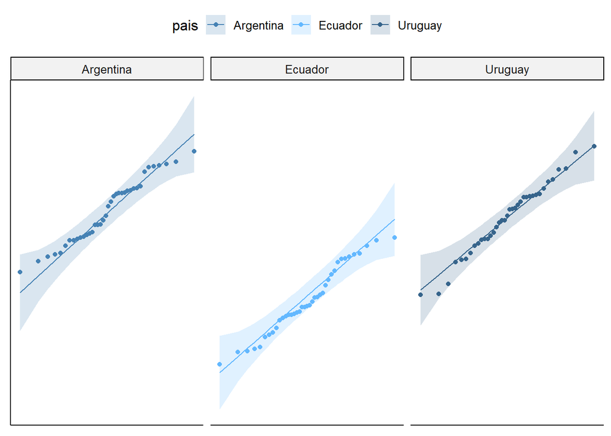

```r
library(ggpubr)
#Comprobar la condición de normalidad con gráficos Q-Q
g1 <- ggqqplot (datosEspecificos, x = "tiempo" , y = "pais" , color = "pais", alpha = 0.5,
                palette = c("steelblue", "steelblue1", "steelblue4") )
g1 <- g1 + facet_wrap(~ pais)
g1 <- g1 + rremove ("x.ticks") + rremove ("x.text")
g1 <- g1 + rremove ("y.ticks") + rremove ("y.text")
g1 <- g1 + rremove ("axis.title")
print (g1)
```

Dentro de los gráficos se puede observar que los datos siguen una distribución normal, para confirmar esto se realizan Shapiro test.

```r
#Se filtran los datos por país
argentina = filter(datosEspecificos, pais == "Argentina")
ecuador = filter(datosEspecificos, pais == "Ecuador")
uruguay = filter(datosEspecificos, pais == "Uruguay")

#Se realizan los shapiro test por cada pais
shapiro.test(argentina$tiempo)
```

```
##
##  Shapiro-Wilk normality test
##
## data:  argentina$tiempo
## W = 0.95731, p-value = 0.1551
```

```r
shapiro.test(ecuador$tiempo)
```

```
##
##  Shapiro-Wilk normality test
##
## data:  ecuador$tiempo
## W = 0.96434, p-value = 0.2482
```

```r
shapiro.test(uruguay$tiempo)
```

```
##
##  Shapiro-Wilk normality test
##
## data:  uruguay$tiempo
## W = 0.98183, p-value = 0.7934
```

Considerando un nivel de significancia $\alpha = 0.05$ no se rechaza la hipótesis de que las 3 poblaciones sigan una distribución normal, por lo que esta condición se cumple.

- Las poblaciones tienen una misma varianza: para ello se utilizara la homogeneidad de las varianzas a través de la prueba de Levene al realizar el test ANOVA.

# Test ANOVA de una vía para muestras independientes

Ya con las condiciones verificadas se procede a hacer el test

```r
library(ez)

#Se realiza Test ANOVA de una vía para muestras independientes
pruebaGeneral <- ezANOVA(data = datosEspecificos, dv = tiempo, wid = X, between = pais, return_aov = TRUE, detailed = TRUE)
```

```
## Coefficient covariances computed by hccm()
```

```r
pruebaGeneral
```

```
## $ANOVA
##   Effect DFn DFd     SSn      SSd        F          p p<.05       ges
## 1   pais   2 111 31.5042 21.86359 79.97235 3.0942e-22     * 0.5903223
##
## $`Levene's Test for Homogeneity of Variance`
##   DFn DFd        SSn      SSd          F         p p<.05
## 1   2 111 0.01130613 6.930136 0.09054512 0.9135005
##
## $aov
## Call:
##    aov(formula = formula(aov_formula), data = data)
##
## Terms:
##                     pais Residuals
## Sum of Squares  31.50420  21.86359
## Deg. of Freedom        2       111
##
## Residual standard error: 0.4438123
## Estimated effects may be unbalanced
```

Los resultados de la prueba muestran dos tablas, la primera entrega los resultados del test ANOVA y la segunda los resultados de la prueba de Levene, esta última tiene un resultado aproximado de p=0,914, y utilizando un nivel de significancia de 0,05 no se rechaza la hipótesis de que hay homogeneidad de las varianzas, por lo que los resultados del test ANOVA son válidos.

El test ANOVA (primera tabla) da un p-value mucho menor a 0,05, por lo tanto, se rechaza la hipótesis nula en favor de la hipótesis alternativa, la cual establece que existe una diferencia notable entre los tiempos medios para resolver el cubo Megaminx de participantes de Ecuador, Uruguay y Argentina.

# Prueba Post Hoc

En el punto anterior logramos deducir que si existe una diferencia significativa entre al menos un par de grupos en la competencia. Ahora vamos a realizar pruebas a posteriori para exponer cuáles son los grupos que difieren entre sí, y llegar a una conclusión más provechosa para la Asociación Mundial del Cubo.

Para tener una idea inicial de la forma de las medias, es útil analizar gráficamente el tamaño del efecto de la prueba ANOVA realizada. Esto sirve como un acercamiento preliminar a qué factores nos interesan inferir en la prueba post-hoc.

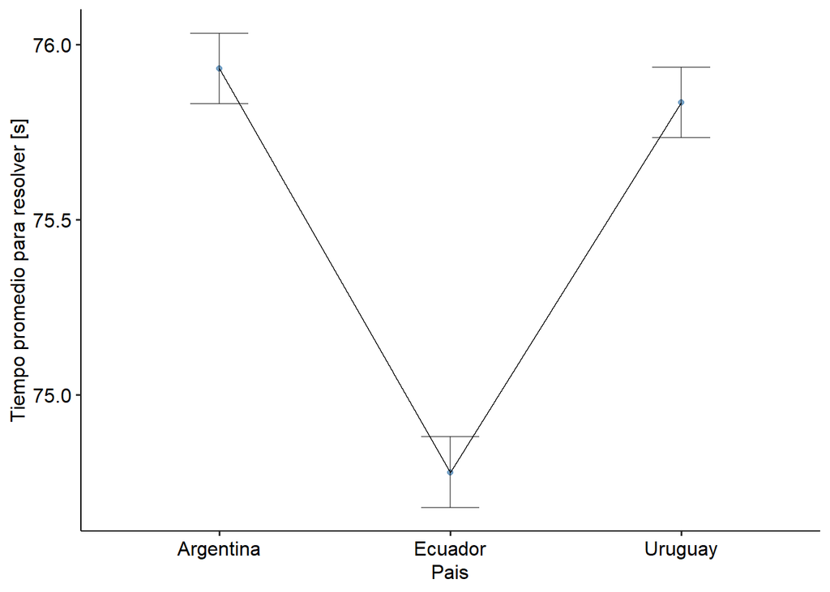

```r
graficoEfecto <- ezPlot(data = datosEspecificos, dv = tiempo, wid = X, between = pais,
                        y_lab = "Tiempo promedio para resolver [s]", x_lab = "Pais", x = pais)
graficoEfecto <- graficoEfecto + theme_pubr()
graficoEfecto[["layers"]][[1]][["aes_params"]] <- list(colour = "steelblue" , alpha = 0.7)

print(graficoEfecto)
```

Para saber si esta suposición es cierta, y obtener conclusiones sólidas, procedemos a usar múltiples pruebas t con las correcciones de Holm y Benjamini y Hochberg, para después aplicar la prueba de comparación de Scheffé con el fin de comparar la media de cada país con el resto.

La razón de porque no se eligió la prueba HSD de Tukey es a que su característica principal de controlar la tasa de error por familia de hipótesis, ofreciendo mayor potencia estadística que otros métodos para controlar la tasa de error, es garantizada al cumplir dos condiciones: los grupos tienen la misma cantidad de observaciones y se cumplen las condiciones para la prueba ANOVA. Está claro que la segunda condición se cumple, pero la primera no. Por ende, no hay razón de considerarla.

```r
library(DescTools)

alfa = 0.05

#Procedimiento con Holm
holm <- pairwise.t.test(datosEspecificos[["tiempo"]], datosEspecificos[["pais"]],
                        p.adj = "holm", pool.sd = TRUE, paired = FALSE, conf.level = 1 - alfa)
print(holm)
```

```
##
##  Pairwise comparisons using t tests with pooled SD
##
## data:  datosEspecificos[["tiempo"]] and datosEspecificos[["pais"]]
##
##         Argentina Ecuador
## Ecuador <2e-16    -
## Uruguay 0.35      <2e-16
##
## P value adjustment method: holm
```

```r
#Procedimiento con Benjamini y Hochberg
bnh <- pairwise.t.test(datosEspecificos[["tiempo"]], datosEspecificos[["pais"]],
                        p.adj = "fdr", pool.sd = TRUE, paired = FALSE, conf.level = 1 - alfa)
print(bnh)
```

```
##
##  Pairwise comparisons using t tests with pooled SD
##
## data:  datosEspecificos[["tiempo"]] and datosEspecificos[["pais"]]
##
##         Argentina Ecuador
## Ecuador <2e-16    -
## Uruguay 0.35      <2e-16
##
## P value adjustment method: fdr
```

```r
#Matriz de contrastes
contrastes <- matrix(c(1, -0.5, -0.5,
                       -0.5, 1, -0.5,
                       -0.5, -0.5, 1),
                     ncol = 3, byrow = TRUE)
contrastes <- t(contrastes)

#Prueba de comparacion de Scheffe
scheffe <- ScheffeTest(x = pruebaGeneral$aov, which = "pais", contrasts = contrastes, conf.level = 1 - alfa)
scheffe
```

```
##
##   Posthoc multiple comparisons of means: Scheffe Test
##     95% family-wise confidence level
##
## $pais
##                                 diff     lwr.ci     upr.ci    pval
## Argentina-Ecuador,Uruguay  0.6245244  0.4057197  0.8433291 1.0e-09 ***
## Ecuador-Argentina,Uruguay -1.1043724 -1.3217703 -0.8869745 < 2e-16 ***
## Uruguay-Argentina,Ecuador  0.4798480  0.2595702  0.7001258 2.3e-06 ***
##
## ---
## Signif. codes:  0 '***' 0.001 '**' 0.01 '*' 0.05 '.' 0.1 ' ' 1
```

Continuamos con interpretar los resultados de los procedimientos post-hoc. Primero, para las pruebas t múltiples, ambas correcciones nos dan los mismos resultados, lo que demuestra que los resultados tienen concordancia. El valor p en el par Argentina-Uruguay no es menor al nivel de significancia elegido, por lo tanto, se favorece la hipótesis nula sobre la alternativa, lo que significa que en promedio no hay diferencia significativa entre los tiempos de Argentina y Uruguay. Los otros pares, Argentina-Ecuador y Ecuador-Uruguay tienen un valor p mucho menor a la significancia, por lo tanto, se concluye que existe una diferencia significativa entre estos pares de grupos.

Respecto de la prueba de Scheffé, todos los valores p de los contrastes es menor a la significancia, así que se rechaza la hipótesis de que no hay diferencia entre cada país y el resto. Sin embargo, es aún más interesante fijar nuestra atención en la diferencia reportada por la prueba. Los contrastes de Argentina y Uruguay muestran una diferencia positiva, lo que se interpreta como que el tiempo promedio de Argentina y Uruguay es mayor al promedio entre los tiempos representativos del resto de países. Sin embargo, la fila de Ecuador tiene una diferencia negativa y de mayor magnitud que las otras diferencias. Esto se traduce a que el tiempo de Ecuador es menor al promedio de los tiempos de Argentina y Uruguay.

Con esto último podemos concluir que, con un 95% de confianza e intervalo de confianza $[-1,322, -0,887]$, el tiempo medio para resolver el cubo Megaminx de los participantes de Ecuador es menor que el promedio de los tiempos de Argentina y Uruguay.

# Conclusión

Finalmente, después de entender la pregunta de la Asociación Mundial del Cubo, analizar el conjunto de datos entregado para responder la pregunta, realizar la prueba ómnibus para obtener resultados generales y procedimientos post-hoc para resultados más específicos, podemos concluir, con 95% de confianza, que sí existen diferencias significativas en promedio entre los tiempos de resolución del cubo Megaminx entre participantes de Argentina, Ecuador y Uruguay, y más en específico Ecuador presenta un tiempo menor que Argentina y Uruguay.